# Assignment_3

Harsha Singh

04/03/2021

## R Markdown

Question:1 Please use data set COVID19.csv for next questions. This data set is in a raw format. You have to clean this dataset before any analysis. Data set is totally raw downloaded from worldmeters today (March 1st 2021) (https://www.worldometers.info/coronavirus/). Hence, data cleaning and manipulation are required. Please also explain your results with numerical summary as well as graphs, wherever it is applicable. Please check your data also, if it is skewed or normally distributed. Results should be based on skewness or normal distribution.

The COVID19.csv data set is raw data extracted from Worldometer (March 1st, 2021). Use COVID19.csv data to answer the questions considering the following:

–> The data set requires data cleaning and manipulation before any analysis. –> Explain your results with a numerical summary and graphs, wherever it is applicable. –> The results should be based on skewness or normal distribution, therefore, do check your data if it is skewed or normally distributed.

```r
## Read the covid csv file dataset
library(readr)
getwd()
```

```
## [1] "D:/GreyCampus/R_Programming/Code/R_Programming_Grey"
```

```r
Covid19_Data = read.csv("Covid19.csv")
str(Covid19_Data)
```

```
## 'data.frame':    237 obs. of  20 variables:
##  $ X                  : int  1 2 3 4 5 6 7 8 9 10 ...
##  $ X.                 : int  NA NA NA NA NA NA NA NA 1 2 ...
##  $ Country.Other      : chr  "North America" "Asia" "South America" "Europe" ...
##  $ TotalCases         : chr  "33,565,070" "25,006,779" "17,991,688" "34,149,236" ...
##  $ NewCases           : chr  "+3,360" "+2,278" "+463" "+2,097" ...
##  $ TotalDeaths        : chr  "759,891" "398,356" "466,860" "813,232" ...
##  $ NewDeaths          : int  468 36 21 25 NA NA NA 550 NA NA ...
##  $ TotalRecovered     : chr  "23,248,152" "23,518,954" "16,259,018" "23,698,937" ...
##  $ NewRecovered       : chr  "+3,964" "+3,406" "+479" "+165" ...
##  $ ActiveCases        : chr  "9,557,027" "1,089,469" "1,265,810" "9,637,067" ...
##  $ Serious.Critical   : chr  "21,321" "21,930" "18,955" "25,544" ...
##  $ Tot.Cases.1M.pop   : chr  "" "" "" "" ...
##  $ Deaths.1M.pop      : chr  "" "" "" "" ...
##  $ TotalTests         : chr  "" "" "" "" ...
##  $ Tests.1M.pop       : chr  "" "" "" "" ...
##  $ Population         : chr  "" "" "" "" ...
##  $ Continent          : chr  "North America" "Asia" "South America" "Europe" ...
##  $ X1.Caseevery.X.ppl : chr  "" "" "" "" ...
##  $ X1.Deathevery.X.ppl: chr  "" "" "" "" ...
##  $ X1.Testevery.X.ppl : chr  "" "" "" "" ...
```

```r
library(dplyr)
```

```r
library(ggplot2)
library(ggpubr)
glimpse(Covid19_Data)
```

```
## Rows: 237
## Columns: 20
## $ X                   <int> 1, 2, 3, 4, 5, 6, 7, 8, 9, 10, 11, 12, 13, 14, ...
## $ X.                  <int> NA, NA, NA, NA, NA, NA, NA, NA, 1, 2, 3, 4, 5, ...
## $ Country.Other       <chr> "North America", "Asia", "South America", "Euro...
## $ TotalCases          <chr> "33,565,070", "25,006,779", "17,991,688", "34,1...
## $ NewCases            <chr> "+3,360", "+2,278", "+463", "+2,097", "", "+7",...
## $ TotalDeaths         <chr> "759,891", "398,356", "466,860", "813,232", "10...
## $ NewDeaths           <int> 468, 36, 21, 25, NA, NA, NA, 550, NA, NA, NA, N...
## $ TotalRecovered      <chr> "23,248,152", "23,518,954", "16,259,018", "23,6...
## $ NewRecovered        <chr> "+3,964", "+3,406", "+479", "+165", "", "+7", "...
## $ ActiveCases         <chr> "9,557,027", "1,089,469", "1,265,810", "9,637,0...
## $ Serious.Critical    <chr> "21,321", "21,930", "18,955", "25,544", "2,555"...
## $ Tot.Cases.1M.pop    <chr> "", "", "", "", "", "", "", "14,714", "88,042",...
## $ Deaths.1M.pop       <chr> "", "", "", "", "", "", "", "326.3", "1,582", "...
## $ TotalTests          <chr> "", "", "", "", "", "", "", "", "359,021,570", ...
## $ Tests.1M.pop        <chr> "", "", "", "", "", "", "", "", "1,080,451", "1...
## $ Population          <chr> "", "", "", "", "", "", "", "", "332,288,557", ...
## $ Continent           <chr> "North America", "Asia", "South America", "Euro...
## $ X1.Caseevery.X.ppl  <chr> "", "", "", "", "", "", "", "", "11", "125", "2...
## $ X1.Deathevery.X.ppl <chr> "", "", "", "", "", "", "", "", "632", "8,836",...
## $ X1.Testevery.X.ppl  <chr> "", "", "", "", "", "", "", "", "1", "6", "7", ...
```

View first 10 rows and last 10 rows to examine the data

```r
head(Covid19_Data,10)
```

```
##     X X. Country.Other  TotalCases NewCases TotalDeaths NewDeaths
## 1   1 NA North America  33,565,070   +3,360     759,891       468
## 2   2 NA          Asia  25,006,779   +2,278     398,356        36
## 3   3 NA South America  17,991,688     +463     466,860        21
## 4   4 NA        Europe  34,149,236   +2,097     813,232        25
## 5   5 NA        Africa   3,924,598              103,868        NA
## 6   6 NA       Oceania      51,168       +7       1,088        NA
## 7   7 NA                       721                   15        NA
## 8   8 NA         World 114,689,260   +8,205   2,543,310       550
## 9   9  1           USA  29,255,344              525,776        NA
## 10 10  2         India  11,112,241     +185     157,195        NA
##    TotalRecovered NewRecovered ActiveCases Serious.Critical Tot.Cases.1M.pop
## 1      23,248,152       +3,964   9,557,027           21,321
## 2      23,518,954       +3,406   1,089,469           21,930
## 3      16,259,018         +479   1,265,810           18,955
```

[output cut: 29 more lines]

```r
tail(Covid19_Data,10)
```

```
##       X  X. Country.Other  TotalCases NewCases TotalDeaths NewDeaths
## 228 228 220       Vanuatu           1                             NA
## 229 229 221         China      89,912      +19       4,636        NA
## 230 230  NA        Total:  33,565,070   +3,360     759,891       468
## 231 231  NA        Total:  25,006,779   +2,278     398,356        36
## 232 232  NA        Total:  17,991,688     +463     466,860        21
## 233 233  NA        Total:  34,149,236   +2,097     813,232        25
## 234 234  NA        Total:   3,924,598              103,868        NA
## 235 235  NA        Total:      51,168       +7       1,088        NA
## 236 236  NA        Total:         721                   15        NA
## 237 237  NA        Total: 114,689,260   +8,205   2,543,310       550
##     TotalRecovered NewRecovered ActiveCases Serious.Critical Tot.Cases.1M.pop
## 228              1                        0                                 3
## 229         85,066          +27         210                1               62
## 230     23,248,152       +3,964   9,557,027           21,321
```

[output cut: 29 more lines]

We observe that the first 8 rows are not country specific info, but overall continent wise.So drop first 8 Same with last 8 rows which are having total calculations which is not relevant to the analysis.So drop last 8 columns too. First and second column removed as irrelavant.

```r
Covid19_df <- Covid19_Data[ -c(1:8,230:237),-(1:2) ]
Covid19_df
```

```
##              Country.Other TotalCases NewCases TotalDeaths NewDeaths
## 9                      USA 29,255,344              525,776        NA
## 10                   India 11,112,241     +185     157,195        NA
## 11                  Brazil 10,551,259              255,018        NA
## 12                  Russia  4,246,079               86,122        NA
## 13                      UK  4,176,554              122,849        NA
## 14                  France  3,755,968               86,454        NA
## 15                   Spain  3,188,553               69,142        NA
## 16                   Italy  2,925,265               97,699        NA
## 17                  Turkey  2,701,588               28,569        NA
## 18                 Germany  2,450,294               70,687        NA
## 19                Colombia  2,251,690               59,766        NA
## 20               Argentina  2,107,365               51,965        NA
## 21                  Mexico  2,086,938   +2,810     185,715       458
## 22                  Poland  1,706,986               43,769        NA
```

[output cut: 873 more lines]

```r
rownames(Covid19_df) <- 1:nrow(Covid19_df)
```

Notice 16 rows deleted

```r
glimpse(Covid19_df)
```

```
## Rows: 221
## Columns: 18
## $ Country.Other       <chr> "USA", "India", "Brazil", "Russia", "UK", "Fran...
## $ TotalCases          <chr> "29,255,344", "11,112,241", "10,551,259", "4,24...
## $ NewCases            <chr> "", "+185", "", "", "", "", "", "", "", "", "",...
## $ TotalDeaths         <chr> "525,776", "157,195", "255,018", "86,122", "122...
## $ NewDeaths           <int> NA, NA, NA, NA, NA, NA, NA, NA, NA, NA, NA, NA,...
## $ TotalRecovered      <chr> "19,694,306", "10,786,457", "9,411,033", "3,811...
## $ NewRecovered        <chr> "", "+1,889", "", "", "", "", "", "", "", "", "...
## $ ActiveCases         <chr> "9,035,262", "168,589", "885,208", "348,160", "...
## $ Serious.Critical    <chr> "14,786", "8,944", "8,318", "2,300", "1,971", "...
## $ Tot.Cases.1M.pop    <chr> "88,042", "8,000", "49,407", "29,088", "61,310"...
## $ Deaths.1M.pop       <chr> "1,582", "113", "1,194", "590", "1,803", "1,323...
## $ TotalTests          <chr> "359,021,570", "216,858,774", "28,600,000", "11...
## $ Tests.1M.pop        <chr> "1,080,451", "156,129", "133,920", "760,399", "...
## $ Population          <chr> "332,288,557", "1,388,975,299", "213,559,824", ...
## $ Continent           <chr> "North America", "Asia", "South America", "Euro...
## $ X1.Caseevery.X.ppl  <chr> "11", "125", "20", "34", "16", "17", "15", "21"...
## $ X1.Deathevery.X.ppl <chr> "632", "8,836", "837", "1,695", "555", "756", "...
## $ X1.Testevery.X.ppl  <chr> "1", "6", "7", "1", "1", "1", "1", "2", "3", "2...
```

```r
Covid19_df
```

```
##              Country.Other TotalCases NewCases TotalDeaths NewDeaths
## 1                      USA 29,255,344              525,776        NA
## 2                    India 11,112,241     +185     157,195        NA
## 3                   Brazil 10,551,259              255,018        NA
## 4                   Russia  4,246,079               86,122        NA
## 5                       UK  4,176,554              122,849        NA
## 6                   France  3,755,968               86,454        NA
## 7                    Spain  3,188,553               69,142        NA
## 8                    Italy  2,925,265               97,699        NA
## 9                   Turkey  2,701,588               28,569        NA
## 10                 Germany  2,450,294               70,687        NA
## 11                Colombia  2,251,690               59,766        NA
## 12               Argentina  2,107,365               51,965        NA
## 13                  Mexico  2,086,938   +2,810     185,715       458
## 14                  Poland  1,706,986               43,769        NA
```

[output cut: 873 more lines]

```r
nrow(Covid19_df)
```

```
## [1] 221
```

```r
ncol(Covid19_df)
```

```
## [1] 18
```

```r
summary(Covid19_df$TotalCases)
```

```
##    Length     Class      Mode
##       221 character character
```

View the first 10 rows

```r
head(Covid19_df,10)
```

```
##    Country.Other TotalCases NewCases TotalDeaths NewDeaths TotalRecovered
## 1            USA 29,255,344              525,776        NA     19,694,306
## 2          India 11,112,241     +185     157,195        NA     10,786,457
## 3         Brazil 10,551,259              255,018        NA      9,411,033
## 4         Russia  4,246,079               86,122        NA      3,811,797
## 5             UK  4,176,554              122,849        NA      2,905,317
## 6         France  3,755,968               86,454        NA        254,868
## 7          Spain  3,188,553               69,142        NA      2,647,446
## 8          Italy  2,925,265               97,699        NA      2,405,199
## 9         Turkey  2,701,588               28,569        NA      2,572,234
## 10       Germany  2,450,294               70,687        NA      2,248,400
##    NewRecovered ActiveCases Serious.Critical Tot.Cases.1M.pop Deaths.1M.pop
## 1                 9,035,262           14,786           88,042         1,582
## 2        +1,889     168,589            8,944            8,000           113
## 3                   885,208            8,318           49,407         1,194
```

[output cut: 29 more lines]

View last 10

```r
tail(Covid19_df,10)
```

```
##         Country.Other TotalCases NewCases TotalDeaths NewDeaths TotalRecovered
## 212          Anguilla         18                             NA             18
## 213   Solomon Islands         18                             NA             14
## 214    Western Sahara         10                    1        NA              8
## 215        MS Zaandam          9                    2        NA              7
## 216 Wallis and Futuna          9                             NA              7
## 217  Marshall Islands          4                             NA              4
## 218             Samoa          3                             NA              2
## 219        Micronesia          1                             NA              1
## 220           Vanuatu          1                             NA              1
## 221             China     89,912      +19       4,636        NA         85,066
##     NewRecovered ActiveCases Serious.Critical Tot.Cases.1M.pop Deaths.1M.pop
## 212                        0                             1,193
## 213                        4                                26
## 214                        1                                16             2
```

[output cut: 29 more lines]

So, we observe the country specific values only there. Let’s remove the duplicate rows now if exist Let’s clean the data to achieve below: Step 1: Keep rows containing country information and remove the rest of the rows. Apart from the country, you should not be having any other row. Move on to the next step only after finishing this.

```r
Covid19_df = unique(Covid19_df)
Covid19_df
```

```
##              Country.Other TotalCases NewCases TotalDeaths NewDeaths
## 1                      USA 29,255,344              525,776        NA
## 2                    India 11,112,241     +185     157,195        NA
## 3                   Brazil 10,551,259              255,018        NA
## 4                   Russia  4,246,079               86,122        NA
## 5                       UK  4,176,554              122,849        NA
## 6                   France  3,755,968               86,454        NA
## 7                    Spain  3,188,553               69,142        NA
## 8                    Italy  2,925,265               97,699        NA
## 9                   Turkey  2,701,588               28,569        NA
## 10                 Germany  2,450,294               70,687        NA
## 11                Colombia  2,251,690               59,766        NA
## 12               Argentina  2,107,365               51,965        NA
## 13                  Mexico  2,086,938   +2,810     185,715       458
## 14                  Poland  1,706,986               43,769        NA
```

[output cut: 873 more lines]

```r
glimpse(Covid19_df)
```

```
## Rows: 221
## Columns: 18
## $ Country.Other       <chr> "USA", "India", "Brazil", "Russia", "UK", "Fran...
## $ TotalCases          <chr> "29,255,344", "11,112,241", "10,551,259", "4,24...
## $ NewCases            <chr> "", "+185", "", "", "", "", "", "", "", "", "",...
## $ TotalDeaths         <chr> "525,776", "157,195", "255,018", "86,122", "122...
## $ NewDeaths           <int> NA, NA, NA, NA, NA, NA, NA, NA, NA, NA, NA, NA,...
## $ TotalRecovered      <chr> "19,694,306", "10,786,457", "9,411,033", "3,811...
## $ NewRecovered        <chr> "", "+1,889", "", "", "", "", "", "", "", "", "...
## $ ActiveCases         <chr> "9,035,262", "168,589", "885,208", "348,160", "...
## $ Serious.Critical    <chr> "14,786", "8,944", "8,318", "2,300", "1,971", "...
## $ Tot.Cases.1M.pop    <chr> "88,042", "8,000", "49,407", "29,088", "61,310"...
## $ Deaths.1M.pop       <chr> "1,582", "113", "1,194", "590", "1,803", "1,323...
## $ TotalTests          <chr> "359,021,570", "216,858,774", "28,600,000", "11...
## $ Tests.1M.pop        <chr> "1,080,451", "156,129", "133,920", "760,399", "...
## $ Population          <chr> "332,288,557", "1,388,975,299", "213,559,824", ...
## $ Continent           <chr> "North America", "Asia", "South America", "Euro...
## $ X1.Caseevery.X.ppl  <chr> "11", "125", "20", "34", "16", "17", "15", "21"...
## $ X1.Deathevery.X.ppl <chr> "632", "8,836", "837", "1,695", "555", "756", "...
## $ X1.Testevery.X.ppl  <chr> "1", "6", "7", "1", "1", "1", "1", "2", "3", "2...
```

```r
Covid19_df[Covid19_df==""|Covid19_df==" "]<-NA
```

```r
summary(Covid19_df)
```

```
##  Country.Other       TotalCases          NewCases         TotalDeaths
##  Length:221         Length:221         Length:221         Length:221
##  Class :character   Class :character   Class :character   Class :character
##  Mode  :character   Mode  :character   Mode  :character   Mode  :character
##
##
##
##
##    NewDeaths   TotalRecovered     NewRecovered       ActiveCases
##  Min.   : 10   Length:221         Length:221         Length:221
##  1st Qu.: 21   Class :character   Class :character   Class :character
##  Median : 25   Mode  :character   Mode  :character   Mode  :character
##  Mean   :110
##  3rd Qu.: 36
##  Max.   :458
##  NA's   :216
##  Serious.Critical   Tot.Cases.1M.pop   Deaths.1M.pop       TotalTests
##  Length:221         Length:221         Length:221         Length:221
##  Class :character   Class :character   Class :character   Class :character
##  Mode  :character   Mode  :character   Mode  :character   Mode  :character
##
##
##
##
##  Tests.1M.pop        Population         Continent         X1.Caseevery.X.ppl
##  Length:221         Length:221         Length:221         Length:221
##  Class :character   Class :character   Class :character   Class :character
##  Mode  :character   Mode  :character   Mode  :character   Mode  :character
##
##
##
##
##  X1.Deathevery.X.ppl X1.Testevery.X.ppl
##  Length:221          Length:221
##  Class :character    Class :character
##  Mode  :character    Mode  :character
##
##
##
##
```

Step 2: Calculate the missing percentage of each column using a function. If any column has missing data more than 5%, please remove it. (Do not try this for rows) Define function:

```r
missing_percent<-function(x)
{
  (sum(is.na(x))/length(x))*100
}

missing_col_percent <- apply(Covid19_df,2,missing_percent)
missing_col_percent
```

```
##       Country.Other          TotalCases            NewCases         TotalDeaths
##           0.0000000           0.0000000          94.5701357           8.1447964
##           NewDeaths      TotalRecovered        NewRecovered         ActiveCases
##          97.7375566           0.0000000          94.5701357           0.0000000
##    Serious.Critical    Tot.Cases.1M.pop       Deaths.1M.pop          TotalTests
##          33.4841629           0.9049774           9.0497738           8.1447964
##        Tests.1M.pop          Population           Continent  X1.Caseevery.X.ppl
##           8.1447964           0.9049774           0.9049774           0.9049774
## X1.Deathevery.X.ppl  X1.Testevery.X.ppl
##           9.0497738           8.1447964
```

```r
Covid19_df[missing_col_percent>5]
```

```
##     NewCases TotalDeaths NewDeaths NewRecovered Serious.Critical Deaths.1M.pop
## 1       <NA>     525,776        NA         <NA>           14,786         1,582
## 2       +185     157,195        NA       +1,889            8,944           113
## 3       <NA>     255,018        NA         <NA>            8,318         1,194
## 4       <NA>      86,122        NA         <NA>            2,300           590
## 5       <NA>     122,849        NA         <NA>            1,971         1,803
## 6       <NA>      86,454        NA         <NA>            3,430         1,323
## 7       <NA>      69,142        NA         <NA>            3,021         1,478
## 8       <NA>      97,699        NA         <NA>            2,231         1,617
## 9       <NA>      28,569        NA         <NA>            1,191           336
## 10      <NA>      70,687        NA         <NA>            2,848           842
## 11      <NA>      59,766        NA         <NA>            2,240         1,166
## 12      <NA>      51,965        NA         <NA>            3,505         1,143
## 13    +2,810     185,715       458       +3,898            4,798         1,430
## 14      <NA>      43,769        NA         <NA>            1,503         1,157
```

[output cut: 429 more lines]

Remove new deaths

```r
Covid19_df <- subset(Covid19_df, select = -(NewDeaths))
ncol(Covid19_df)
```

```
## [1] 17
```

One column reduced

```r
colnames(Covid19_df)
```

```
##  [1] "Country.Other"       "TotalCases"          "NewCases"
##  [4] "TotalDeaths"         "TotalRecovered"      "NewRecovered"
##  [7] "ActiveCases"         "Serious.Critical"    "Tot.Cases.1M.pop"
## [10] "Deaths.1M.pop"       "TotalTests"          "Tests.1M.pop"
## [13] "Population"          "Continent"           "X1.Caseevery.X.ppl"
## [16] "X1.Deathevery.X.ppl" "X1.Testevery.X.ppl"
```

```r
glimpse(Covid19_df)
```

```
## Rows: 221
## Columns: 17
## $ Country.Other       <chr> "USA", "India", "Brazil", "Russia", "UK", "Fran...
## $ TotalCases          <chr> "29,255,344", "11,112,241", "10,551,259", "4,24...
## $ NewCases            <chr> NA, "+185", NA, NA, NA, NA, NA, NA, NA, NA, NA,...
## $ TotalDeaths         <chr> "525,776", "157,195", "255,018", "86,122", "122...
## $ TotalRecovered      <chr> "19,694,306", "10,786,457", "9,411,033", "3,811...
## $ NewRecovered        <chr> NA, "+1,889", NA, NA, NA, NA, NA, NA, NA, NA, N...
## $ ActiveCases         <chr> "9,035,262", "168,589", "885,208", "348,160", "...
## $ Serious.Critical    <chr> "14,786", "8,944", "8,318", "2,300", "1,971", "...
## $ Tot.Cases.1M.pop    <chr> "88,042", "8,000", "49,407", "29,088", "61,310"...
## $ Deaths.1M.pop       <chr> "1,582", "113", "1,194", "590", "1,803", "1,323...
## $ TotalTests          <chr> "359,021,570", "216,858,774", "28,600,000", "11...
## $ Tests.1M.pop        <chr> "1,080,451", "156,129", "133,920", "760,399", "...
## $ Population          <chr> "332,288,557", "1,388,975,299", "213,559,824", ...
## $ Continent           <chr> "North America", "Asia", "South America", "Euro...
## $ X1.Caseevery.X.ppl  <chr> "11", "125", "20", "34", "16", "17", "15", "21"...
## $ X1.Deathevery.X.ppl <chr> "632", "8,836", "837", "1,695", "555", "756", "...
## $ X1.Testevery.X.ppl  <chr> "1", "6", "7", "1", "1", "1", "1", "2", "3", "2...
```

Observe data has +,“,”,N/A

```r
head(Covid19_df,30)
```

```
##    Country.Other TotalCases NewCases TotalDeaths TotalRecovered NewRecovered
## 1            USA 29,255,344     <NA>     525,776     19,694,306         <NA>
## 2          India 11,112,241     +185     157,195     10,786,457       +1,889
## 3         Brazil 10,551,259     <NA>     255,018      9,411,033         <NA>
## 4         Russia  4,246,079     <NA>      86,122      3,811,797         <NA>
## 5             UK  4,176,554     <NA>     122,849      2,905,317         <NA>
## 6         France  3,755,968     <NA>      86,454        254,868         <NA>
## 7          Spain  3,188,553     <NA>      69,142      2,647,446         <NA>
## 8          Italy  2,925,265     <NA>      97,699      2,405,199         <NA>
## 9         Turkey  2,701,588     <NA>      28,569      2,572,234         <NA>
## 10       Germany  2,450,294     <NA>      70,687      2,248,400         <NA>
## 11      Colombia  2,251,690     <NA>      59,766      2,148,249         <NA>
## 12     Argentina  2,107,365     <NA>      51,965      1,905,021         <NA>
## 13        Mexico  2,086,938   +2,810     185,715      1,633,900       +3,898
## 14        Poland  1,706,986     <NA>      43,769      1,422,829         <NA>
```

[output cut: 109 more lines]

```r
#Replace occurences
Covid19_df<-data.frame(lapply(Covid19_df, gsub, pattern = ",|\\+|N/A", replacement = ""))
Covid19_df<-data.frame(lapply(Covid19_df, gsub, pattern =" ", replacement = ""))


Covid19_df
```

```
##            Country.Other TotalCases NewCases TotalDeaths TotalRecovered
## 1                    USA   29255344     <NA>      525776       19694306
## 2                  India   11112241      185      157195       10786457
## 3                 Brazil   10551259     <NA>      255018        9411033
## 4                 Russia    4246079     <NA>       86122        3811797
## 5                     UK    4176554     <NA>      122849        2905317
## 6                 France    3755968     <NA>       86454         254868
## 7                  Spain    3188553     <NA>       69142        2647446
## 8                  Italy    2925265     <NA>       97699        2405199
## 9                 Turkey    2701588     <NA>       28569        2572234
## 10               Germany    2450294     <NA>       70687        2248400
## 11              Colombia    2251690     <NA>       59766        2148249
## 12             Argentina    2107365     <NA>       51965        1905021
## 13                Mexico    2086938     2810      185715        1633900
## 14                Poland    1706986     <NA>       43769        1422829
```

[output cut: 873 more lines]

```r
#Check first 30 rows if N/A also removed
head(Covid19_df,30)
```

```
##    Country.Other TotalCases NewCases TotalDeaths TotalRecovered NewRecovered
## 1            USA   29255344     <NA>      525776       19694306         <NA>
## 2          India   11112241      185      157195       10786457         1889
## 3         Brazil   10551259     <NA>      255018        9411033         <NA>
## 4         Russia    4246079     <NA>       86122        3811797         <NA>
## 5             UK    4176554     <NA>      122849        2905317         <NA>
## 6         France    3755968     <NA>       86454         254868         <NA>
## 7          Spain    3188553     <NA>       69142        2647446         <NA>
## 8          Italy    2925265     <NA>       97699        2405199         <NA>
## 9         Turkey    2701588     <NA>       28569        2572234         <NA>
## 10       Germany    2450294     <NA>       70687        2248400         <NA>
## 11      Colombia    2251690     <NA>       59766        2148249         <NA>
## 12     Argentina    2107365     <NA>       51965        1905021         <NA>
## 13        Mexico    2086938     2810      185715        1633900         3898
## 14        Poland    1706986     <NA>       43769        1422829         <NA>
```

[output cut: 109 more lines]

```r
## Can see for example row 21's N/A removed
```

Step 3: Give a better column name after cleaning your data.

```r
colnames(Covid19_df)[colnames(Covid19_df) %in% c("Country.Other", "TotalCases","NewCases","TotalDeaths","TotalRecovered","NewRecovered","ActiveCases","Serious.Critical","Tot.Cases.1M.pop", "Deaths.1M.pop","TotalTests", "Tests.1M.pop", "Population", "Continent","X1.Caseevery.X.ppl", "X1.Deathevery.X.ppl", "X1.Testevery.X.ppl")] <- c("Country", "Total_Cases", "New_Cases","Total_Deaths","Total_Recovered","New_Recovered","Active_Cases","Critical","Total_Cases_pmp", "Deaths_pmp","Total_Tests", "Tests_pmp", "Population", "Continent","Case every X ppl", "Death every X ppl", "Test every X ppl")
colnames(Covid19_df)
```

```
##  [1] "Country"           "Total_Cases"       "New_Cases"
##  [4] "Total_Deaths"      "Total_Recovered"   "New_Recovered"
##  [7] "Active_Cases"      "Critical"          "Total_Cases_pmp"
## [10] "Deaths_pmp"        "Total_Tests"       "Tests_pmp"
## [13] "Population"        "Continent"         "Case every X ppl"
## [16] "Death every X ppl" "Test every X ppl"
```

```r
summary(Covid19_df)
```

```
##    Country          Total_Cases         New_Cases         Total_Deaths
##  Length:221         Length:221         Length:221         Length:221
##  Class :character   Class :character   Class :character   Class :character
##  Mode  :character   Mode  :character   Mode  :character   Mode  :character
##  Total_Recovered    New_Recovered      Active_Cases         Critical
##  Length:221         Length:221         Length:221         Length:221
##  Class :character   Class :character   Class :character   Class :character
##  Mode  :character   Mode  :character   Mode  :character   Mode  :character
##  Total_Cases_pmp     Deaths_pmp        Total_Tests         Tests_pmp
##  Length:221         Length:221         Length:221         Length:221
##  Class :character   Class :character   Class :character   Class :character
##  Mode  :character   Mode  :character   Mode  :character   Mode  :character
##   Population         Continent         Case every X ppl   Death every X ppl
##  Length:221         Length:221         Length:221         Length:221
##  Class :character   Class :character   Class :character   Class :character
##  Mode  :character   Mode  :character   Mode  :character   Mode  :character
##  Test every X ppl
##  Length:221
##  Class :character
##  Mode  :character
```

```r
library(dplyr)
    # convert to numeric
    Covid19_df <- Covid19_df %>%mutate_at(c(2:13,15:17), as.numeric,na.rm = TRUE)
    Covid19_df
```

```
##                  Country Total_Cases New_Cases Total_Deaths Total_Recovered
## 1                    USA    29255344        NA       525776        19694306
## 2                  India    11112241       185       157195        10786457
## 3                 Brazil    10551259        NA       255018         9411033
## 4                 Russia     4246079        NA        86122         3811797
## 5                     UK     4176554        NA       122849         2905317
## 6                 France     3755968        NA        86454          254868
## 7                  Spain     3188553        NA        69142         2647446
## 8                  Italy     2925265        NA        97699         2405199
## 9                 Turkey     2701588        NA        28569         2572234
## 10               Germany     2450294        NA        70687         2248400
## 11              Colombia     2251690        NA        59766         2148249
## 12             Argentina     2107365        NA        51965         1905021
## 13                Mexico     2086938      2810       185715         1633900
## 14                Poland     1706986        NA        43769         1422829
```

[output cut: 873 more lines]

Let’s convert continents to factors

```r
    Covid19_df <- Covid19_df %>%mutate_at(c(14), as.factor)
```

```r
summary(Covid19_df)
```

```
##    Country           Total_Cases         New_Cases       Total_Deaths
##  Length:221         Min.   :       1   Min.   :   2.0   Min.   :     1.0
##  Class :character   1st Qu.:    3390   1st Qu.:  18.0   1st Qu.:    84.5
##  Mode  :character   Median :   28975   Median : 324.0   Median :   622.0
##                     Mean   :  518956   Mean   : 683.8   Mean   : 12528.6
##                     3rd Qu.:  219592   3rd Qu.: 814.5   3rd Qu.:  4664.0
##                     Max.   :29255344   Max.   :2810.0   Max.   :525776.0
##                                        NA's   :209      NA's   :18
##  Total_Recovered    New_Recovered     Active_Cases        Critical
##  Min.   :       1   Min.   :   7.0   Min.   :    -62   Min.   :    1.0
##  1st Qu.:    2353   1st Qu.:  54.0   1st Qu.:    222   1st Qu.:   11.0
##  Median :   19447   Median : 255.5   Median :   2700   Median :   66.0
##  Mean   :  411969   Mean   : 802.1   Mean   :  92270   Mean   :  614.4
##  3rd Qu.:  181266   3rd Qu.: 940.2   3rd Qu.:  18246   3rd Qu.:  392.5
##  Max.   :19694306   Max.   :3898.0   Max.   :9035262   Max.   :14786.0
##  NA's   :2          NA's   :211      NA's   :2         NA's   :74
##  Total_Cases_pmp    Deaths_pmp      Total_Tests          Tests_pmp
##  Min.   :     3   Min.   :   0.2   Min.   :      470   Min.   :    575
##  1st Qu.:  1343   1st Qu.:  28.0   1st Qu.:    98359   1st Qu.:  48097
##  Median : 11278   Median : 152.0   Median :   720678   Median : 191010
##  Mean   : 23092   Mean   : 429.7   Mean   :  8024465   Mean   : 448030
##  3rd Qu.: 39680   3rd Qu.: 626.0   3rd Qu.:  3591831   3rd Qu.: 520958
##  Max.   :140484   Max.   :2761.0   Max.   :359021570   Max.   :5540672
##  NA's   :2        NA's   :20       NA's   :18          NA's   :18
##    Population                    Continent  Case every X ppl
##  Min.   :8.020e+02   Africa           :57   Min.   :     7.0
##  1st Qu.:6.439e+05   Asia             :49   1st Qu.:    25.0
##  Median :6.595e+06   Australia/Oceania:12   Median :    89.0
##  Mean   :3.566e+07   Europe           :48   Mean   :  5238.8
##  3rd Qu.:2.431e+07   NorthAmerica     :39   3rd Qu.:   744.5
##  Max.   :1.439e+09   SouthAmerica     :14   Max.   :311856.0
##  NA's   :2           NA's             : 2   NA's   :2
##  Death every X ppl Test every X ppl
##  Min.   :    362   Min.   :   0.00
##  1st Qu.:   1597   1st Qu.:   2.00
##  Median :   6596   Median :   5.00
##  Mean   : 113535   Mean   :  36.57
##  3rd Qu.:  35162   3rd Qu.:  21.00
##  Max.   :4040802   Max.   :1739.00
##  NA's   :20        NA's   :18
```

```r
class(Covid19_df$Continent)
```

```
## [1] "factor"
```

Now Data is cleaned completely.

##Let’s check if data is skewed or normally distributed:

```r
??psych
```

```
## starting httpd help server ... done
```

```r
##install.packages("psych")
library(psych)
##install.packages("moments")
library(moments)
skewness(Covid19_df[,2:13,15:17],na.rm = TRUE)
```

```
##     Total_Cases       New_Cases    Total_Deaths Total_Recovered   New_Recovered
##        9.926452        1.308732        7.787564        8.475483        1.755641
##    Active_Cases        Critical Total_Cases_pmp      Deaths_pmp     Total_Tests
##       12.055215        5.438010        1.525221        1.494743        7.811932
##       Tests_pmp      Population
##        3.716781        8.845929
```

All the values have skewness value greater than 1, implies highly skewed

```r
#install.packages("dlookr")
library(dlookr)
skewedcols<-c()
skewedcols<-find_skewness(Covid19_df, index = FALSE)
skewedcols
```

```
##  [1] "Total_Cases"       "New_Cases"         "Total_Deaths"
##  [4] "Total_Recovered"   "New_Recovered"     "Active_Cases"
##  [7] "Critical"          "Total_Cases_pmp"   "Deaths_pmp"
## [10] "Total_Tests"       "Tests_pmp"         "Population"
## [13] "Case every X ppl"  "Death every X ppl" "Test every X ppl"
```

Let’s transform data logarithmically to create legible plots

```r
summary(Covid19_df[skewedcols])
```

```
##   Total_Cases         New_Cases       Total_Deaths      Total_Recovered
##  Min.   :       1   Min.   :   2.0   Min.   :     1.0   Min.   :       1
##  1st Qu.:    3390   1st Qu.:  18.0   1st Qu.:    84.5   1st Qu.:    2353
##  Median :   28975   Median : 324.0   Median :   622.0   Median :   19447
##  Mean   :  518956   Mean   : 683.8   Mean   : 12528.6   Mean   :  411969
##  3rd Qu.:  219592   3rd Qu.: 814.5   3rd Qu.:  4664.0   3rd Qu.:  181266
##  Max.   :29255344   Max.   :2810.0   Max.   :525776.0   Max.   :19694306
##                     NA's   :209      NA's   :18         NA's   :2
##  New_Recovered     Active_Cases        Critical       Total_Cases_pmp
##  Min.   :   7.0   Min.   :    -62   Min.   :    1.0   Min.   :     3
##  1st Qu.:  54.0   1st Qu.:    222   1st Qu.:   11.0   1st Qu.:  1343
##  Median : 255.5   Median :   2700   Median :   66.0   Median : 11278
##  Mean   : 802.1   Mean   :  92270   Mean   :  614.4   Mean   : 23092
##  3rd Qu.: 940.2   3rd Qu.:  18246   3rd Qu.:  392.5   3rd Qu.: 39680
##  Max.   :3898.0   Max.   :9035262   Max.   :14786.0   Max.   :140484
##  NA's   :211      NA's   :2         NA's   :74        NA's   :2
##    Deaths_pmp      Total_Tests          Tests_pmp         Population
##  Min.   :   0.2   Min.   :      470   Min.   :    575   Min.   :8.020e+02
##  1st Qu.:  28.0   1st Qu.:    98359   1st Qu.:  48097   1st Qu.:6.439e+05
##  Median : 152.0   Median :   720678   Median : 191010   Median :6.595e+06
##  Mean   : 429.7   Mean   :  8024465   Mean   : 448030   Mean   :3.566e+07
##  3rd Qu.: 626.0   3rd Qu.:  3591831   3rd Qu.: 520958   3rd Qu.:2.431e+07
##  Max.   :2761.0   Max.   :359021570   Max.   :5540672   Max.   :1.439e+09
##  NA's   :20       NA's   :18          NA's   :18        NA's   :2
##  Case every X ppl   Death every X ppl Test every X ppl
##  Min.   :     7.0   Min.   :    362   Min.   :   0.00
##  1st Qu.:    25.0   1st Qu.:   1597   1st Qu.:   2.00
##  Median :    89.0   Median :   6596   Median :   5.00
##  Mean   :  5238.8   Mean   : 113535   Mean   :  36.57
##  3rd Qu.:   744.5   3rd Qu.:  35162   3rd Qu.:  21.00
##  Max.   :311856.0   Max.   :4040802   Max.   :1739.00
##  NA's   :2          NA's   :20        NA's   :18
```

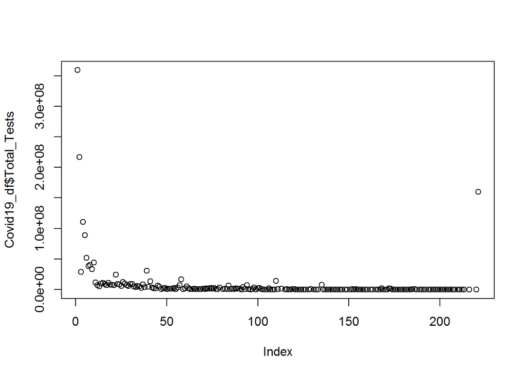

```r
plot(Covid19_df$Total_Tests)
```

Observe that mean is greater than median for above skewed columns.

For 2 columns we have min value as 0,nearing to 0 ie.Deaths_pmp and Test every X ppl Also for column ActiveCases we have negative min value (-62) Transform These first

```r
transformed_df<-Covid19_df
transformed_df$`Test every X ppl`<-transform(Covid19_df$`Test every X ppl`, method = "log+1")

transformed_df
```

```
##                  Country Total_Cases New_Cases Total_Deaths Total_Recovered
## 1                    USA    29255344        NA       525776        19694306
## 2                  India    11112241       185       157195        10786457
## 3                 Brazil    10551259        NA       255018         9411033
## 4                 Russia     4246079        NA        86122         3811797
## 5                     UK     4176554        NA       122849         2905317
## 6                 France     3755968        NA        86454          254868
## 7                  Spain     3188553        NA        69142         2647446
## 8                  Italy     2925265        NA        97699         2405199
## 9                 Turkey     2701588        NA        28569         2572234
## 10               Germany     2450294        NA        70687         2248400
## 11              Colombia     2251690        NA        59766         2148249
## 12             Argentina     2107365        NA        51965         1905021
## 13                Mexico     2086938      2810       185715         1633900
## 14                Poland     1706986        NA        43769         1422829
```

[output cut: 873 more lines]

```r
class(transformed_df)
```

```
## [1] "data.frame"
```

```r
transformed_df[skewedcols] <- lapply(transformed_df[skewedcols], log)
transformed_df$`Test every X ppl`<-transform(Covid19_df$`Test every X ppl`, method = "log+1")
transformed_df$`Active_Cases`<-transform(Covid19_df$`Active_Cases`, method = "log+1")
transformed_df$`Deaths_pmp`<-transform(Covid19_df$`Deaths_pmp`, method = "log+1")
```

```r
summary(transformed_df)
```

```
## * Resolving Skewness with log+1
##
## * Information of Transformation (before vs after)
##               Original Transformation
## n            219.00000    218.0000000
## na             2.00000      3.0000000
## mean       92269.67580      7.3471055
## sd        659993.24009      3.4559921
## se_mean    44598.21018      0.2340693
## IQR        18023.00000      4.4123955
## skewness      12.13851     -0.4273158
## kurtosis     158.98499     -0.3237383
## p00          -62.00000      0.0000000
## p01            0.00000      0.0000000
## p05            0.90000      0.6931472
## p10            5.60000      2.1218302
## p20           77.20000      4.5347223
## p25          222.50000      5.4160709
## p30          344.60000      5.8533453
## p40         1043.60000      6.9866585
## p50         2700.00000      7.9050660
## p60         6630.60000      8.8011680
## p70        10993.00000      9.3079619
## p75        18245.50000      9.8284664
## p80        26631.00000     10.1976450
## p90        71168.00000     11.1843094
## p95       179364.80000     12.1006916
## p99      1101015.60000     13.9096211
## p100     9035262.00000     16.0166456
## * Resolving Skewness with log+1
##
## * Information of Transformation (before vs after)
##             Original Transformation
## n         201.000000    201.0000000
## na         20.000000     20.0000000
## mean      429.745771      4.8460684
## sd        545.947767      1.9353883
## se_mean    38.508186      0.1365118
## IQR       598.000000      3.0736507
## skewness    1.506006     -0.5071308
```

[output cut: 32 more lines]

```
## p05         1.000000      0.6931472
## p10         1.000000      0.6931472
## p20         2.000000      1.0986123
## p25         2.000000      1.0986123
## p30         2.000000      1.0986123
## p40         3.000000      1.3862944
## p50         5.000000      1.7917595
## p60         8.000000      2.1972246
## p70        14.000000      2.7080502
## p75        21.000000      3.0900083
## p80        34.600000      3.5722506
## p90        91.800000      4.5259155
## p95       149.100000      5.0111346
## p99       312.420000      5.7467978
## p100     1739.000000      7.4616404
```

```
##    Country           Total_Cases       New_Cases       Total_Deaths
##  Length:221         Min.   : 0.000   Min.   :0.6932   Min.   : 0.000
##  Class :character   1st Qu.: 8.129   1st Qu.:2.8853   1st Qu.: 4.437
##  Mode  :character   Median :10.274   Median :5.6790   Median : 6.433
##                     Mean   : 9.946   Mean   :4.8909   Mean   : 6.358
##                     3rd Qu.:12.300   3rd Qu.:6.6343   3rd Qu.: 8.448
##                     Max.   :17.192   Max.   :7.9409   Max.   :13.173
##                                      NA's   :209      NA's   :18
##
##
##
##
##
##
##
##
##
##
##
##
##
##
##
##
##
##
##  Total_Recovered  New_Recovered
##  Min.   : 0.000   Min.   :1.946
##  1st Qu.: 7.763   1st Qu.:3.981
##  Median : 9.875   Median :5.476
##  Mean   : 9.664   Mean   :5.328
##  3rd Qu.:12.108   3rd Qu.:6.791
##  Max.   :16.796   Max.   :8.268
##  NA's   :2        NA's   :211
##
##
##
##
##
##
```

[output cut: 127 more lines]

```
##     1.0000000     0.6931472
##     1.0000000     0.6931472
##     2.0000000     1.0986123
##     2.0000000     1.0986123
##     2.0000000     1.0986123
##     3.0000000     1.3862944
##     5.0000000     1.7917595
##     8.0000000     2.1972246
##    14.0000000     2.7080502
##    21.0000000     3.0900083
##    34.6000000     3.5722506
##    91.8000000     4.5259155
##   149.1000000     5.0111346
##   312.4200000     5.7467978
##  1739.0000000     7.4616404
```

```r
typeof(transformed_df$`Test every X ppl`)
```

```
## [1] "double"
```

1.Create plots for total cases, total death, and total recovery. Explain with a figure for each. All are related to human –> therefore they are discrete data

```r
library(ggplot2)
?ggplot
##install.packages("ggpubr")
library("ggpubr")
```

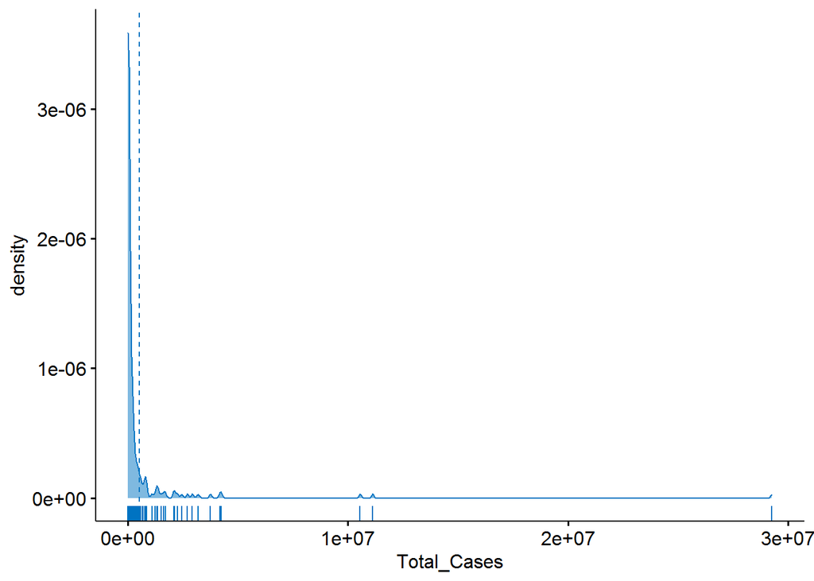

```r
ggdensity(Covid19_df, x = "Total_Cases",fill = "#0073C2FF", color = "#0073C2FF",add = "mean", rug = TRUE)
```

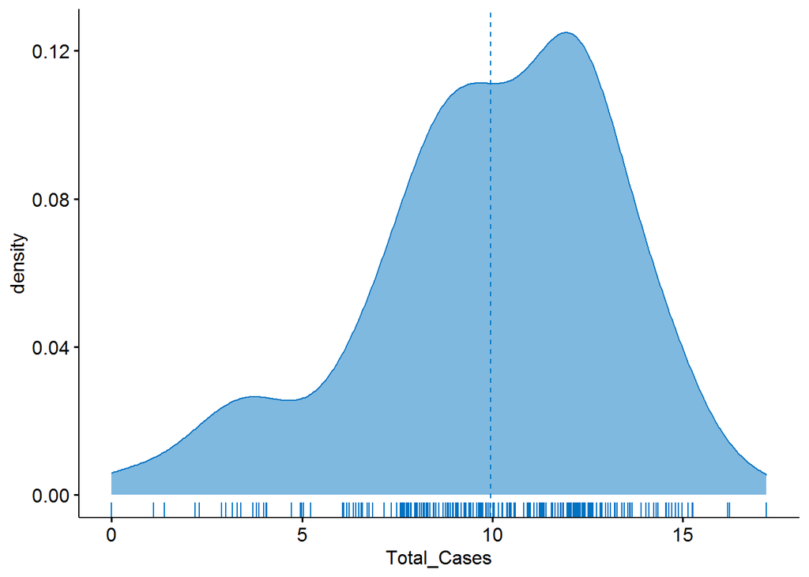

```r
#For normally disributed data we can see, values above 10power of x are more distributed
ggdensity(transformed_df, x = "Total_Cases",fill = "#0073C2FF", color = "#0073C2FF",add = "mean", rug = TRUE)
```

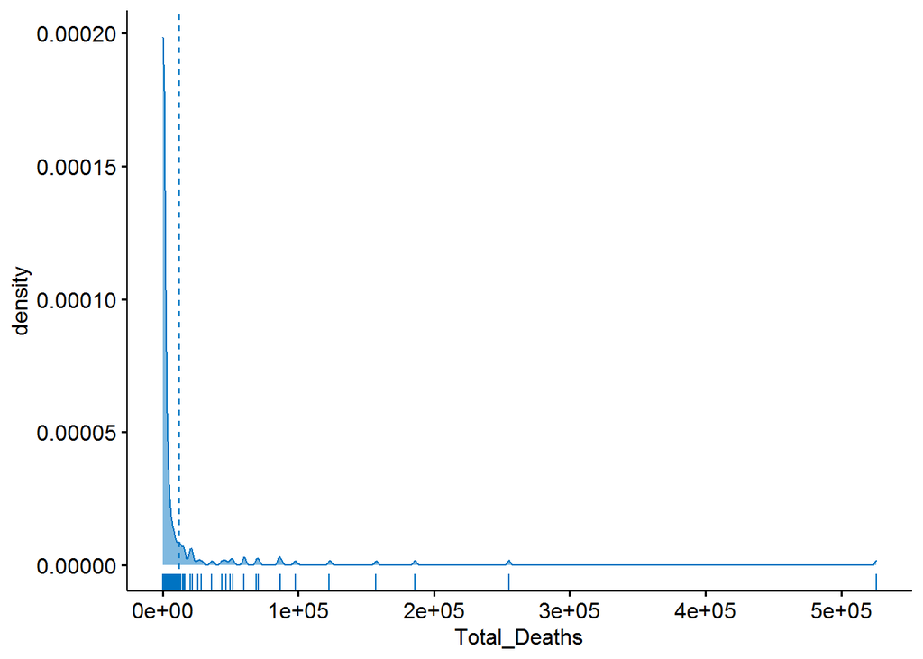

```r
##For continuous variable, you can visualize the distribution of the variable using density plots
ggdensity(Covid19_df, x = "Total_Deaths",fill = "#0073C2FF", color = "#0073C2FF",add = "mean", rug = TRUE)
```

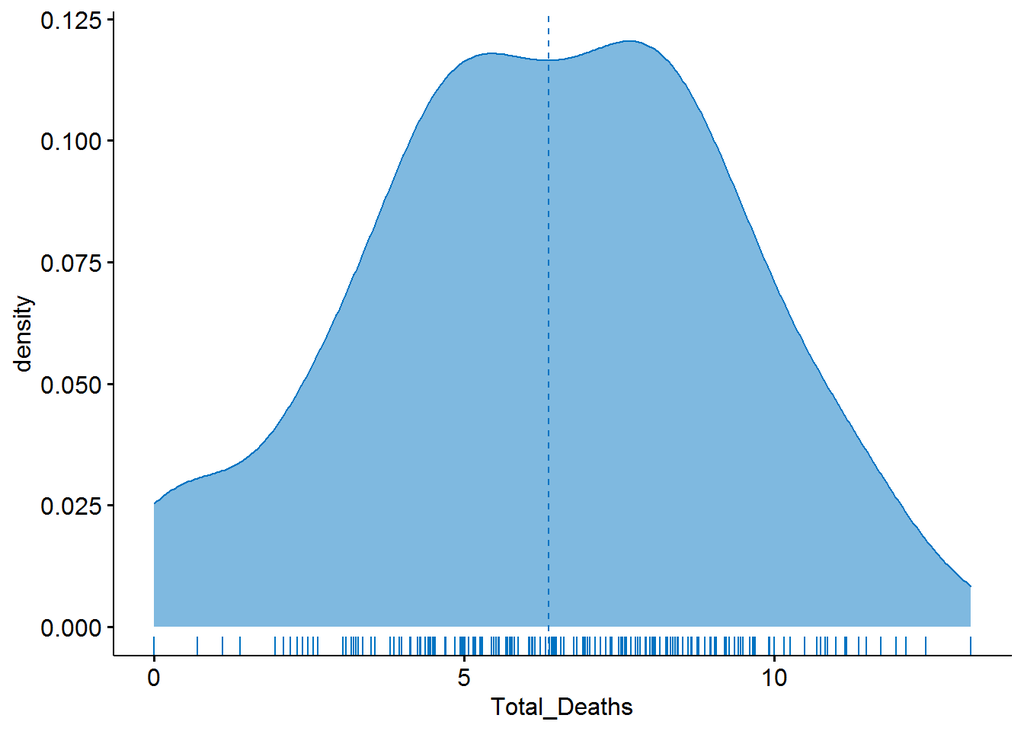

```r
#For normally distributed data we can see, values above 10power of x are more distributed
ggdensity(transformed_df, x = "Total_Deaths",fill = "#0073C2FF", color = "#0073C2FF",add = "mean", rug = TRUE)
```

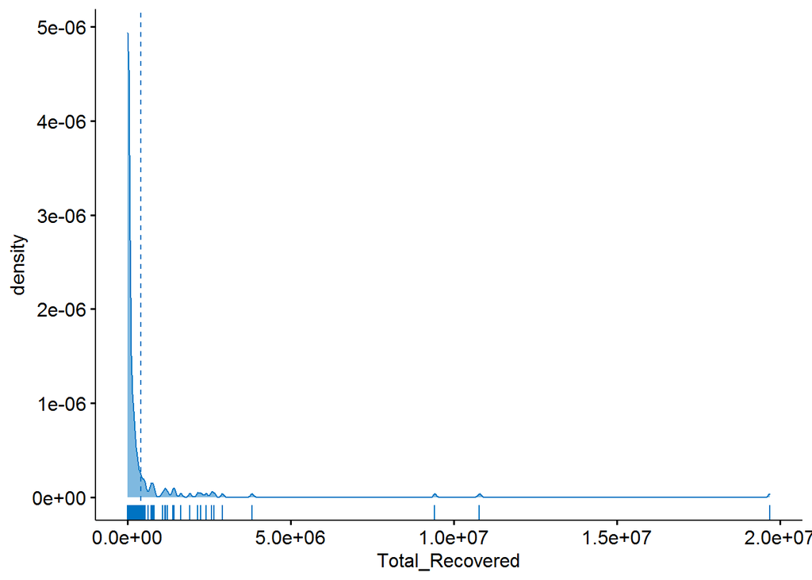

```r
ggdensity(Covid19_df, x = "Total_Recovered",fill = "#0073C2FF", color = "#0073C2FF",add = "mean", rug = TRUE)
```

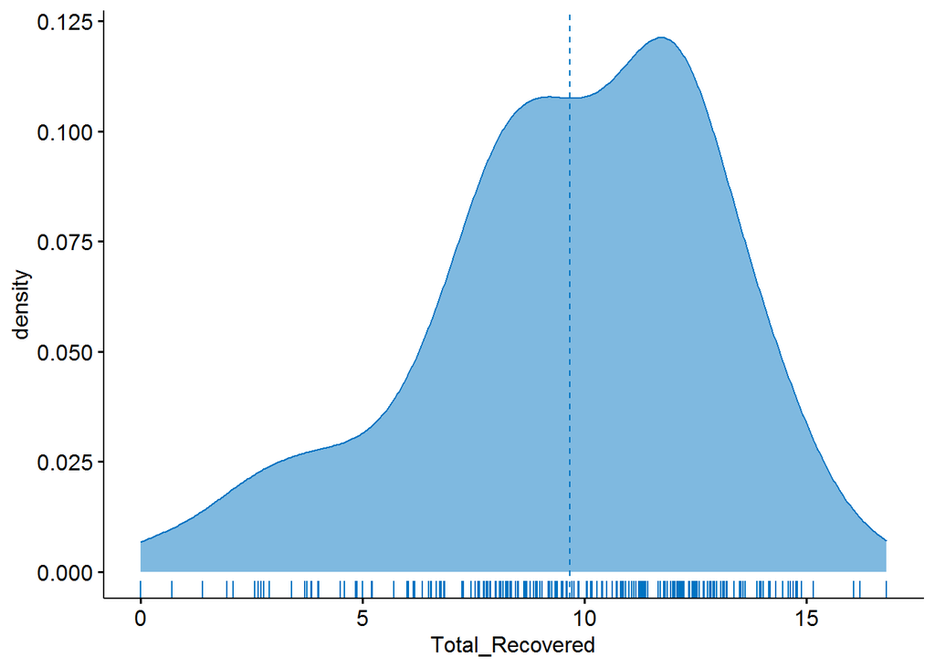

```r
#For normally disributed data we can see, values above 10power of x are more distributed
ggdensity(transformed_df, x = "Total_Recovered",fill = "#0073C2FF", color = "#0073C2FF",add = "mean", rug = TRUE)
```

```r
transformed_df$`Test every X ppl`
```

```
##   [1] 0.6931472 1.9459101 2.0794415 0.6931472 0.6931472 0.6931472 0.6931472
##   [8] 1.0986123 1.3862944 1.0986123 1.6094379 1.9459101 3.2188758 1.6094379
##  [15] 2.1972246 2.0794415 1.9459101 3.2958369 1.6094379 0.6931472 1.0986123
##  [22] 1.0986123 1.0986123 0.6931472 1.3862944 0.6931472 0.6931472 1.9459101
##  [29] 1.0986123 3.2580965 2.6390573 1.0986123 3.7376696 2.0794415 1.0986123
##  [36] 1.3862944 2.7725887 1.3862944 0.0000000 1.0986123 1.3862944 1.0986123
##  [43] 1.0986123 1.3862944 1.7917595 1.0986123 2.9444390 2.7080502 0.6931472
##  [50] 2.8332133 1.6094379 1.3862944 2.3025851 1.6094379 2.5649494 0.6931472
##  [57] 1.3862944 0.0000000 2.1972246 0.6931472 1.0986123 1.0986123 1.0986123
##  [64] 1.9459101 1.6094379 4.6539604 3.0445224 1.6094379 3.1354942 1.0986123
##  [71] 2.3978953 4.0253517 4.9558271 3.1354942 1.3862944 2.3978953 2.3978953
##  [78] 1.7917595 0.6931472        NA 1.9459101 3.7612001 1.6094379 2.1972246
##  [85] 2.3025851 0.6931472 3.5835189 2.4849066 3.2580965 2.8903718 1.0986123
##  [92] 0.6931472 0.6931472 0.6931472 2.3025851 4.3307333 1.3862944 1.0986123
##  [99] 4.8903491 0.0000000 1.7917595 3.9889840 2.1972246 3.8066625 5.2040067
```

[output cut: 37 more lines]

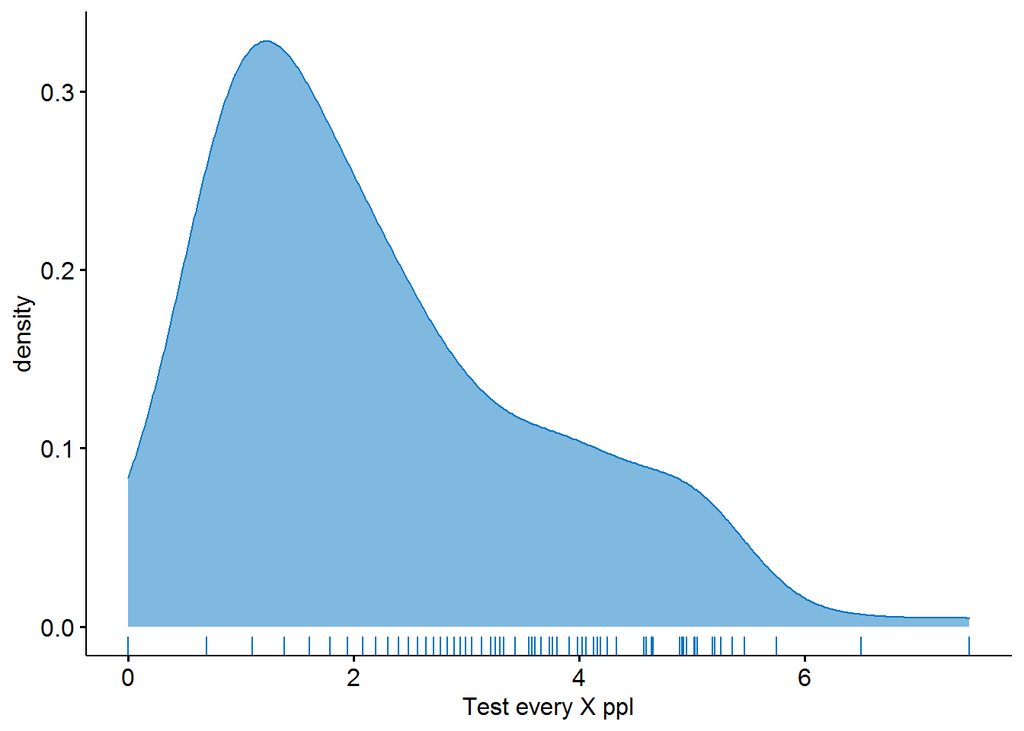

```r
ggdensity(transformed_df, x = "Test every X ppl",fill = "#0073C2FF", color = "#0073C2FF", rug = TRUE)
```

```r
summary(transformed_df$`Test every X ppl`)
```

```
## * Resolving Skewness with log+1
##
## * Information of Transformation (before vs after)
##             Original Transformation
## n         203.000000    203.0000000
## na         18.000000     18.0000000
## mean       36.566502      2.1936641
## sd        136.867643      1.4741634
## se_mean     9.606225      0.1034660
## IQR        19.000000      1.9913960
## skewness   10.201866      0.8796906
## kurtosis  121.444045      0.2153983
## p00         0.000000      0.0000000
## p01         0.000000      0.0000000
## p05         1.000000      0.6931472
## p10         1.000000      0.6931472
## p20         2.000000      1.0986123
## p25         2.000000      1.0986123
## p30         2.000000      1.0986123
## p40         3.000000      1.3862944
## p50         5.000000      1.7917595
## p60         8.000000      2.1972246
## p70        14.000000      2.7080502
## p75        21.000000      3.0900083
## p80        34.600000      3.5722506
## p90        91.800000      4.5259155
## p95       149.100000      5.0111346
## p99       312.420000      5.7467978
## p100     1739.000000      7.4616404
```

```r
median(transformed_df$`Test every X ppl`,na.rm = TRUE)
```

```
## [1] 1.791759
```

```r
mean(transformed_df$`Test every X ppl`,na.rm = TRUE)
```

```
## [1] 2.193664
```

```r
summary(Covid19_df$`Total Cases`)
```

```
## Length  Class   Mode
##      0   NULL   NULL
```

```r
##install.packages("Hmisc")
library(Hmisc)
```

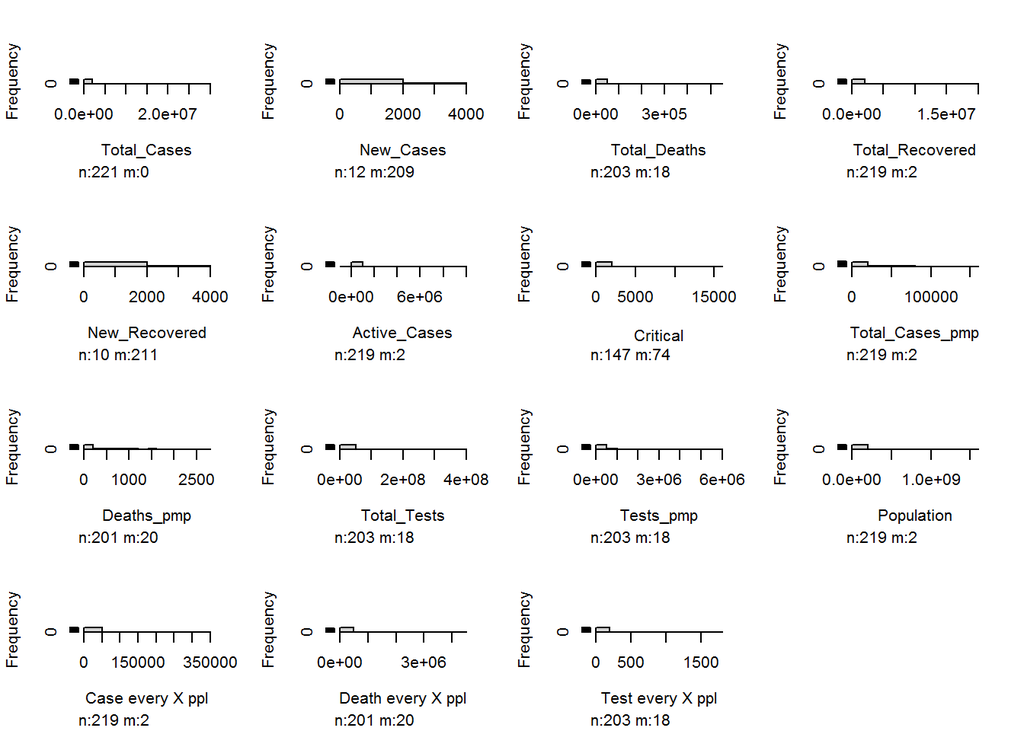

```r
num_data <-Covid19_df[, sapply(Covid19_df, is.numeric)]
hist(num_data,na.rm=T)
```

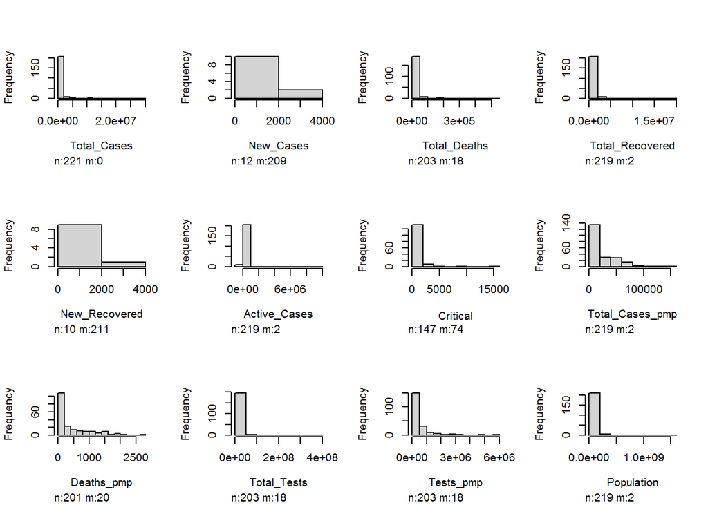

```r
hist(Covid19_df[,2:13,15:17],na.rm = TRUE)
```

From above graphs we can infer data is right skewed completely. Create a plot to examine the correlation between total cases and total population. Explain if there is any correlation between total cases and total population.

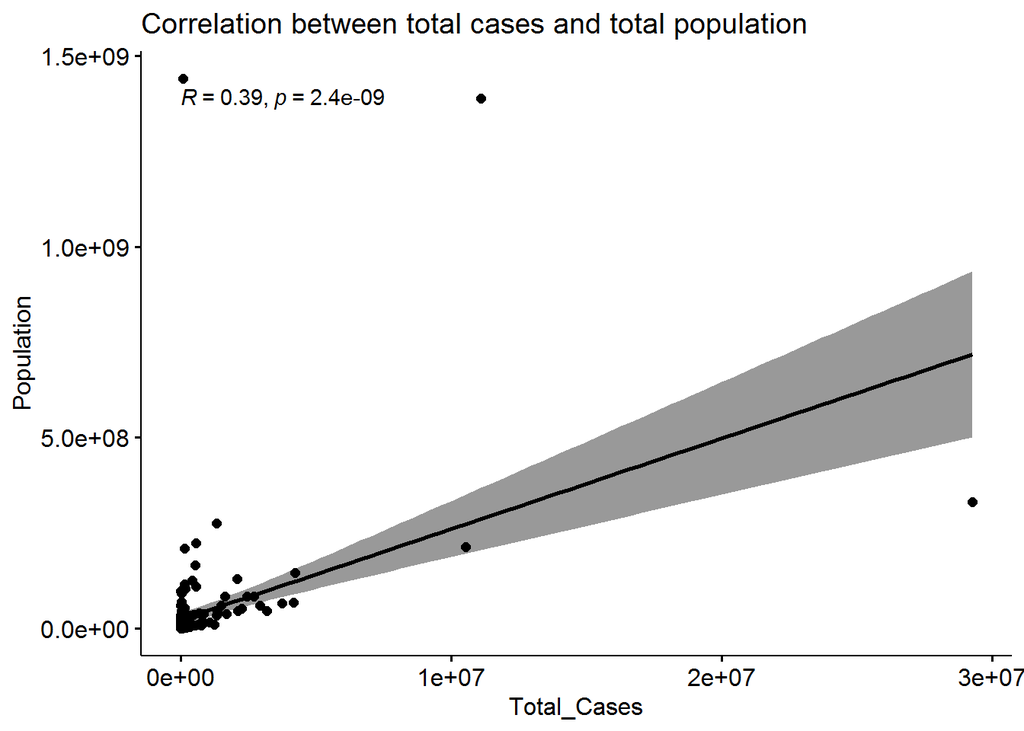

```r
library(ggplot2)
library(ggpubr)

ggscatter(Covid19_df, x="Total_Cases",y="Population",
          add = "reg.line", conf.int = TRUE,
          cor.coef = TRUE, cor.method = "pearson",
          xlab = "Total_Cases", ylab = "Population",main="Correlation between total cases and total population")
```

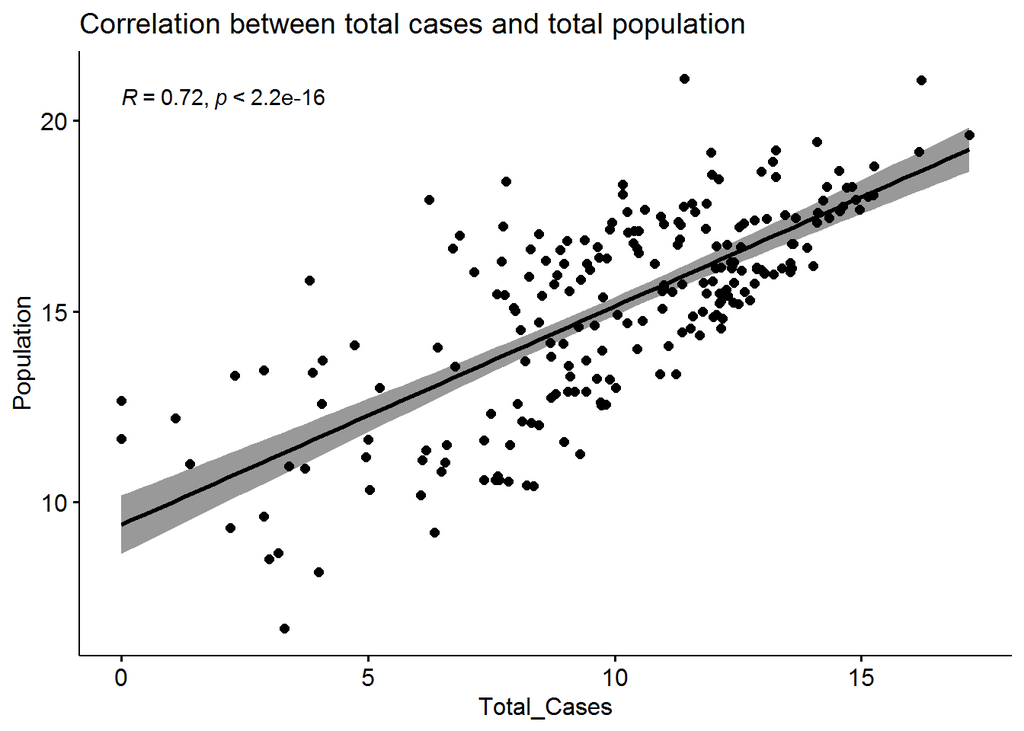

```r
ggscatter(transformed_df, x="Total_Cases",y="Population",
          add = "reg.line", conf.int = TRUE,
          cor.coef = TRUE, cor.method = "pearson",
          xlab = "Total_Cases", ylab = "Population",main="Correlation between total cases and total population")
```

From above graphs we can conclude positive correlation.On skewed data correlation is at lower values but when normally distributed we can see increase in population implies increase in cases.

Create a plot to examine the correlation between Tot Cases/1M pop and total population. Explain if there is any correlation between them?

```r
Covid19_df$Total_Cases_pmp
```

[output not shown]

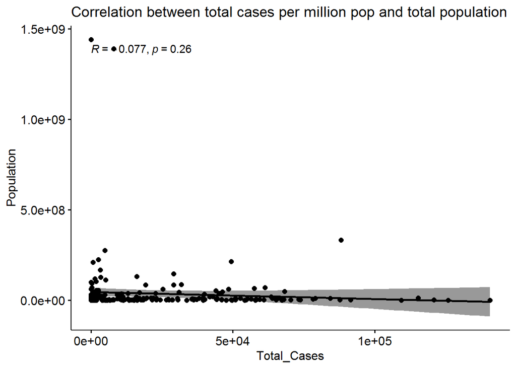

```r
ggscatter(Covid19_df, x="Total_Cases_pmp",y="Population",
          add = "reg.line", conf.int = TRUE,
          cor.coef = TRUE, cor.method = "pearson",
          xlab = "Total_Cases", ylab = "Population",main="Correlation between total cases per million pop and total population")
```

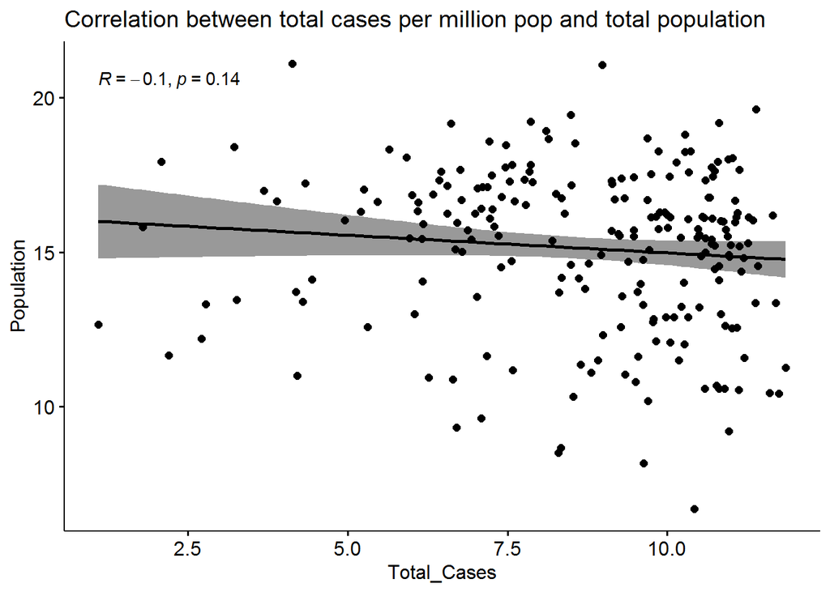

```r
ggscatter(transformed_df, x="Total_Cases_pmp",y="Population",
          add = "reg.line", conf.int = TRUE,
          cor.coef = TRUE, cor.method = "pearson",
          xlab = "Total_Cases", ylab = "Population",main="Correlation between total cases per million pop and total population")
```

No correlation between total_cases/1M Pop and population.

Which column do you feel is better for comparison purposes, total cases or TotCases/1M pop. Explain. Answer:TotCases/1M pop is better Because it groups cases per million population and gives clear info and can infer no correlation. The total cases column correlates with population but it is not clearly generalising.

Create a plot to examine the correlation between total cases and total death. Explain the figure.

```r
Covid19_df$Total_Cases
```

[output not shown]

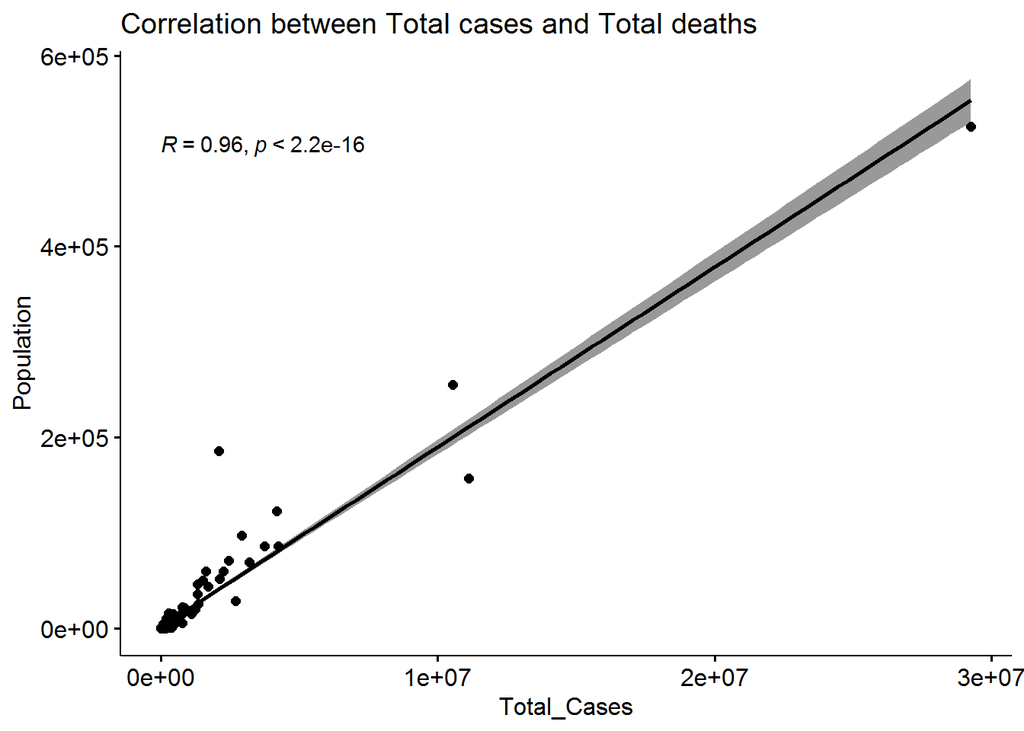

```r
ggscatter(Covid19_df, x="Total_Cases",y="Total_Deaths",
          add = "reg.line", conf.int = TRUE,
          cor.coef = TRUE, cor.method = "pearson",
          xlab = "Total_Cases", ylab = "Population",main="Correlation between Total cases and Total deaths")
```

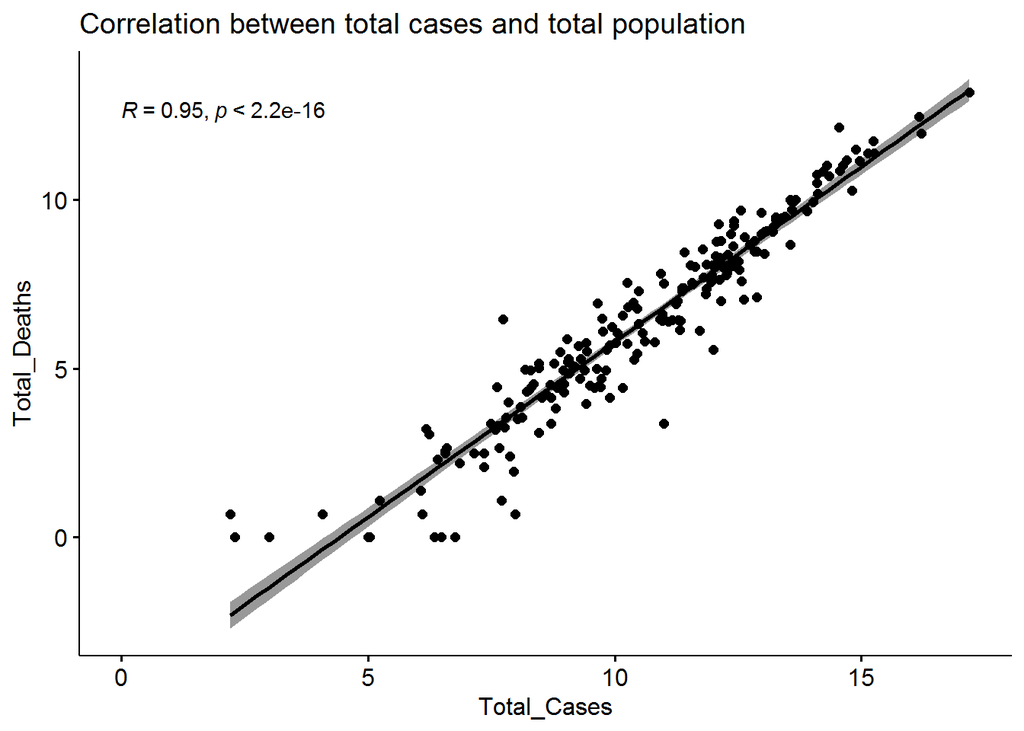

```r
ggscatter(transformed_df, x="Total_Cases",y="Total_Deaths",
          add = "reg.line", conf.int = TRUE,
          cor.coef = TRUE, cor.method = "pearson",
          xlab = "Total_Cases", ylab = "Total_Deaths",main="Correlation between total cases and total population")
```

There is a very high positive correlation here.Implies as cases increase the chances of deaths also increase,After all COVID is a huge pandemic.

Create a plot to examine the correlation between total cases and Deaths/1M pop. Explain the figure. Which column is more suitable to compare the result, total death or Death/1Mpop?

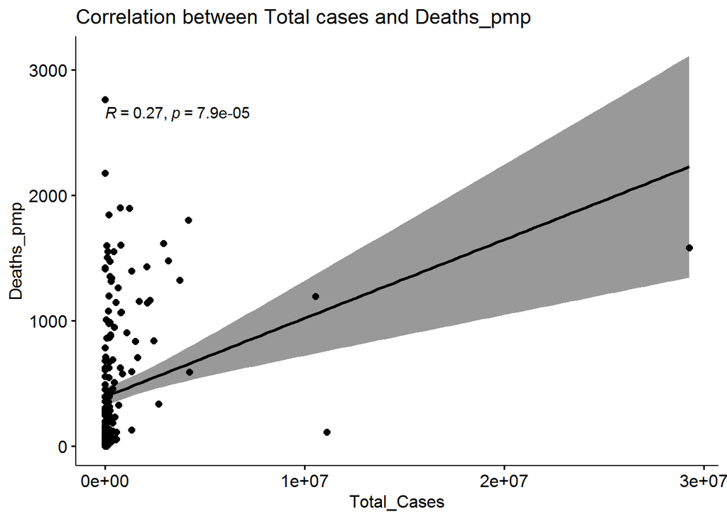

```r
ggscatter(Covid19_df, x="Total_Cases",y="Deaths_pmp",
          add = "reg.line", conf.int = TRUE,
          cor.coef = TRUE, cor.method = "pearson",
          xlab = "Total_Cases", ylab = "Deaths_pmp",main="Correlation between Total cases and Deaths_pmp")
```

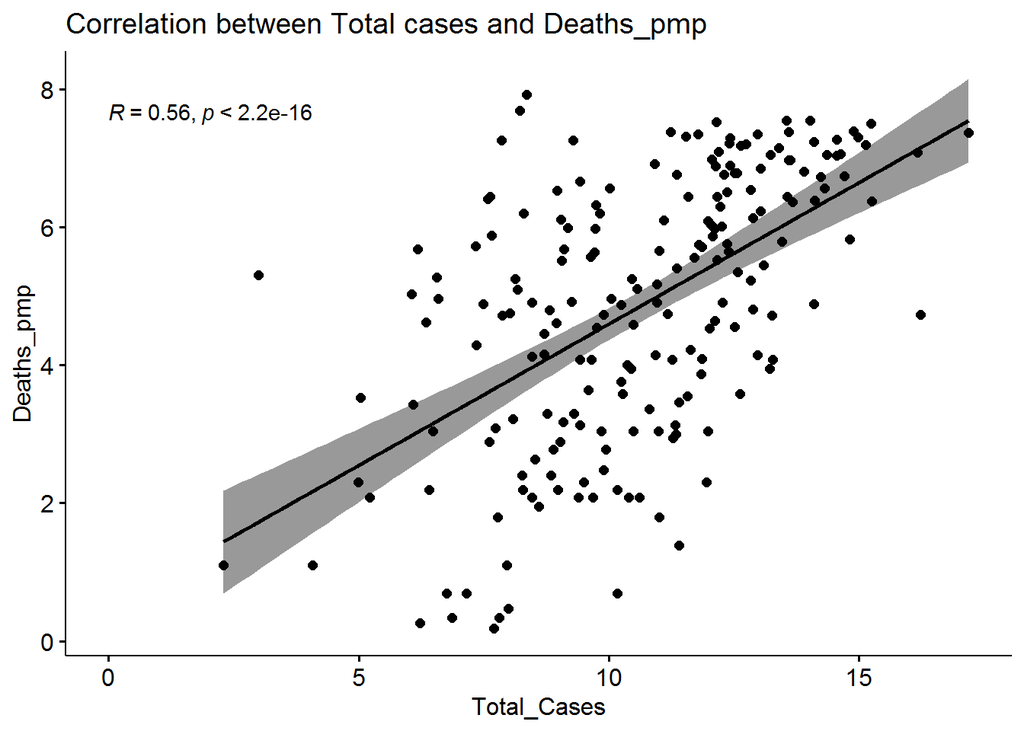

```r
ggscatter(transformed_df, x="Total_Cases",y="Deaths_pmp",
          add = "reg.line", conf.int = TRUE,
          cor.coef = TRUE, cor.method = "pearson",
          xlab = "Total_Cases", ylab = "Deaths_pmp",main="Correlation between Total cases and Deaths_pmp")
```

The total Deaths_pmp gives a clear picture as we see outliers of deaths cases when number of cases are low too.So it is a good option to correlated compared to total_deaths column ______________________

Compare Tot Cases/1M pop by continent, and explain your result.

```r
levels(Covid19_df$Continent)
```

```
## [1] "Africa"            "Asia"              "Australia/Oceania"
## [4] "Europe"            "NorthAmerica"      "SouthAmerica"
```

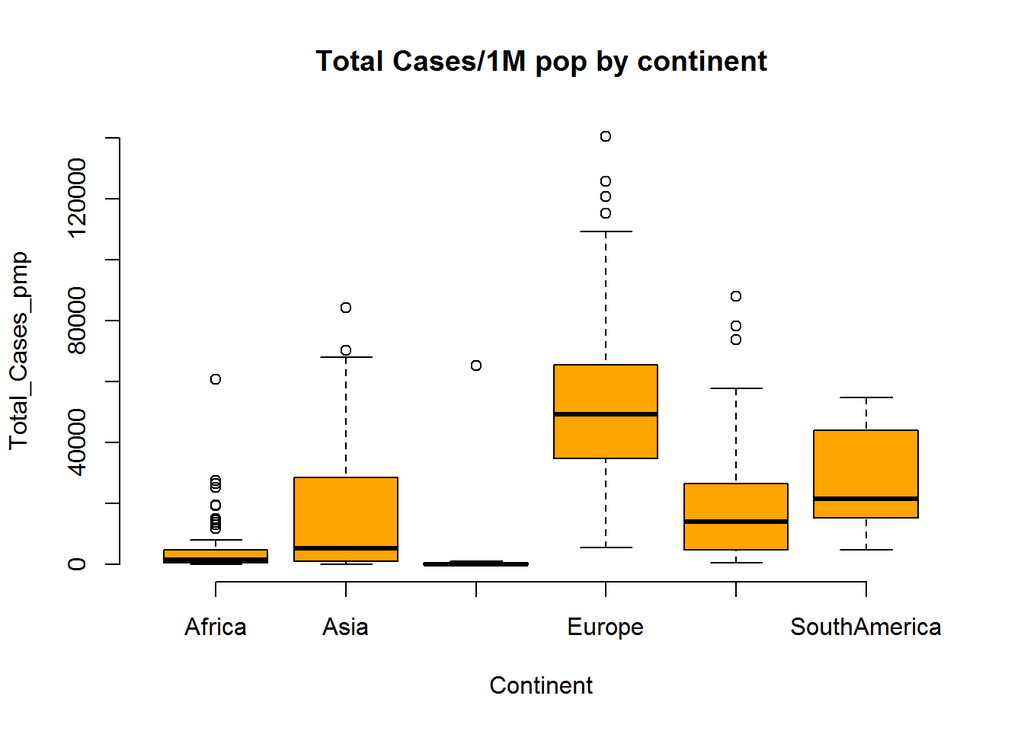

```r
boxplot(Total_Cases_pmp ~ Continent, data = Covid19_df,na.exclude(Covid19_df$Continent),main = "Total Cases/1M pop by continent",col = "orange", frame = FALSE)
```

[figure not shown]

[output not shown]

[figure not shown]

```r
ggplot(Covid19_df, aes(x=Continent, y= Total_Cases_pmp),color="blue", fill="orange") +   geom_boxplot(outlier.colour="red",fill='#F2A7A4', color="blue") + theme_classic() + scale_fill_brewer(palette="Dark2")
```

Compare Deaths/1M pop by continent, and explain your result.

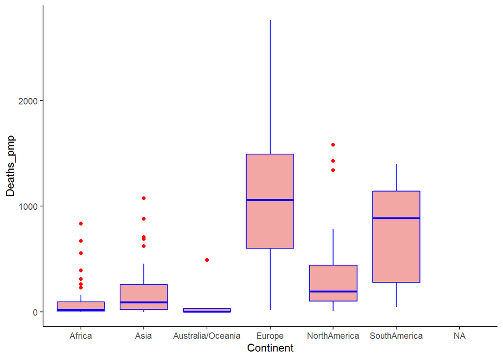

```r
ggplot(Covid19_df, aes(x=Continent, y= Deaths_pmp),color="blue", fill="orange") +   geom_boxplot(outlier.colour="red",fill='#F2A7A4', color="blue") + theme_classic() + scale_fill_brewer(palette="Dark2")
```

Notice 3 things:

1.Europe has highest death cases per million pop 2.Austraila/Ocenia has the least 3.Africa has high number Of outliers

Which country is best among testing the COVID19 and which country is worst? There are two columns total test vs. test/M. Choose appropriate column.

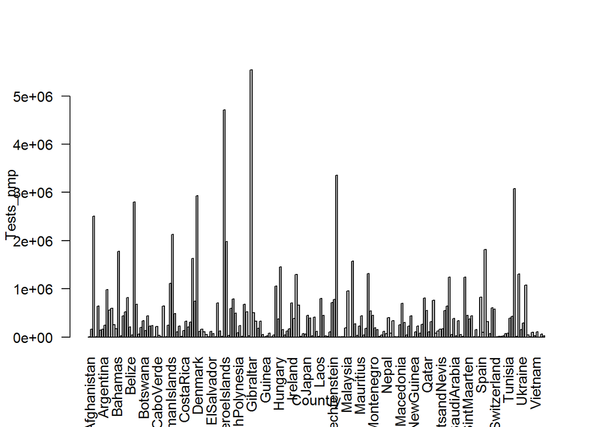

```r
barplot(`Tests_pmp` ~ `Country`,data=Covid19_df, las=2)
```

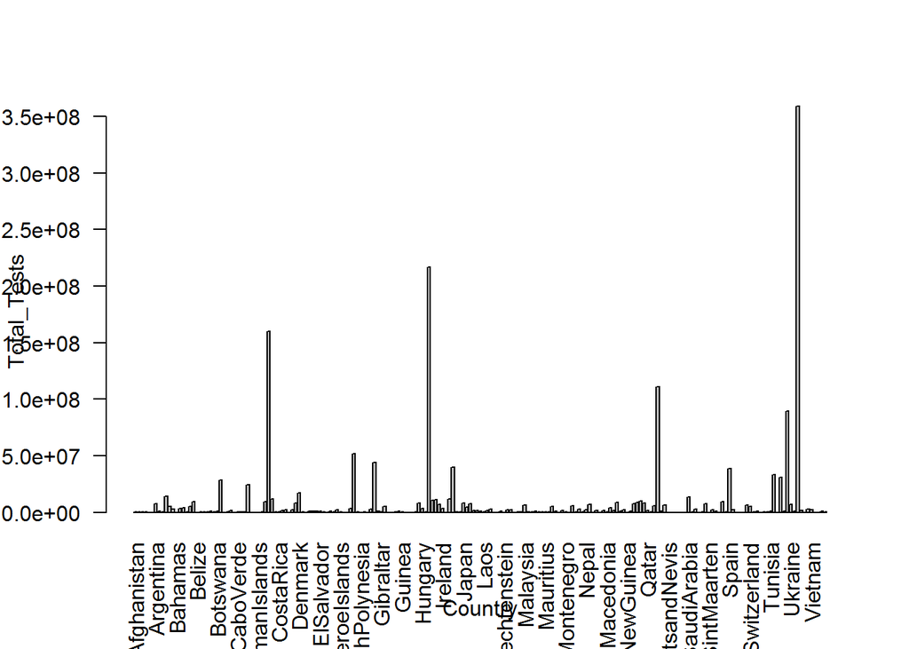

```r
barplot(`Total_Tests` ~ `Country`,data=Covid19_df, las=2)
```

Total_Tests does noy give clear picture so we consider tests_pmp which has weak correlation to population

```r
Covid19_df$Country[which.max(Covid19_df$`Tests_pmp`)]
```

```
## [1] "Gibraltar"
```

best among testing the COVID19 is Gibraltar

```r
Covid19_df$Country[which.min(Covid19_df$`Tests_pmp`)]
```

```
## [1] "Yemen"
```

Worst among testing the COVID19 is Yemen Compare your COVID19 test results by continent? There are two columns total test vs test/M. Choose appropriate column.

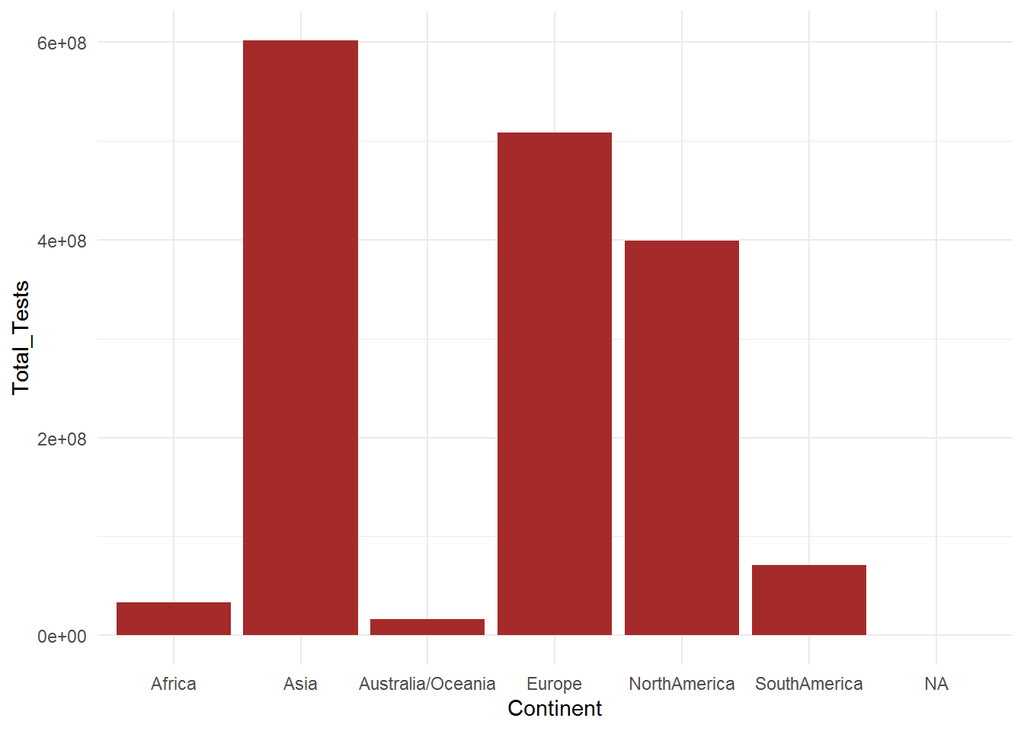

```r
ggplot(data=Covid19_df, aes(x=Continent, y=Total_Tests),frame=TRUE) +
  geom_bar(stat="identity", fill="brown")+
  theme_minimal()
```

cHOOSE Tests_pmp as we already saw it has no significant correlation with population Highest number of tests EUROPE has conducted.Australia is the least

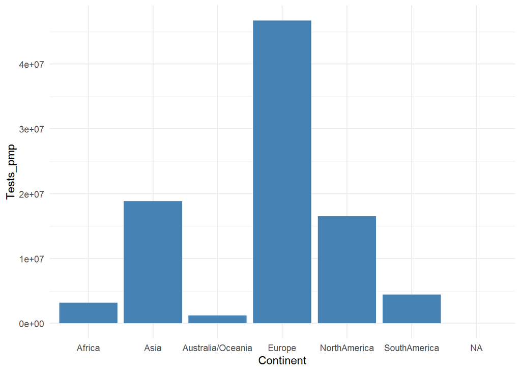

```r
ggplot(data=Covid19_df, aes(x=Continent, y=Tests_pmp)) +
  geom_bar(stat="identity", fill="steelblue")+
  theme_minimal()
```

Check if Tests/1M pop is skewed or normally distributed.

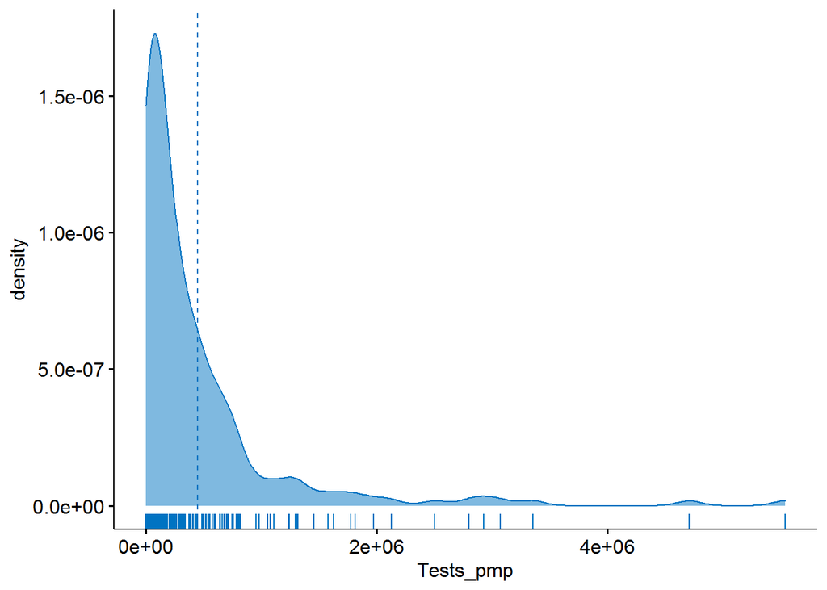

```r
ggdensity(Covid19_df, x = "Tests_pmp",fill = "#0073C2FF", color = "#0073C2FF",add = "mean", rug = TRUE)
```

It is clearly highly right skewed.